# Sla1 patch density in Ede1∆PQCC-Syp1 fusion

Last compiled on March 21, 2022

## Experiment

The aim of the experiment is to determine Sla1 patch density where the central region deletion (PQ-rich and coiled-coil) of Ede1 is attached to Syp1 using the FRB-FKBP system.

### Imaging

All images were captured with the halide lamp @ 50% power using the GFP filter cube and 400 ms exposure per slice. 5 micron stacks were taken with 0.2 micron step.

### List of strains used

| Strain | Mutations |
| --- | --- |
| MKY0140 | wild type |
| MKY0654 | ede1∆ |
| MKY4343 | Ede1∆(366-900)-mCherry-FKBP, SYP1-FRB, fpr1∆, tor1-1 |

All: Sla1-EGFP

MKY4343 was cultured with 10 ug/ml rapamycin (+R) or equivalent volume of solvent (1% DMSO in culture, -R).

### Image processing

Patch numbers were extracted with a custom Python script `site_counter.py` (part of package impromptu called `mkimage`) using functions from the `scikit-image` package. Briefly, the images were median-filter subtracted with a 5 px disk brush and thresholded using the Yen method. The thresholded image was eroded using the number of non-zero neighbouring pixels in 3D as the erosion criterion. The spots were counted using skimage.measure.label() function with 2-connectivity.

Cross-section area was obtained by median-filtering of the stack with 10px disk brush, calculating the maximum projection image, thresholding using Otsu’s algorithm and using skimage.measure.regionprops() to obtain area. Note that these are pixel counts of *cross-section* area. To determine the total surface area, I assume that an unbudded cell is spherical (suface area is four times the cross-section area).

This call to `site_counter` was used to process all datasets:

```
process_folder(path, median_radius = 5, erosion_n = 1, con = 2,
                   method = Yen, mask = False, loop = False, save_images = True)
```

`data_cleanup.Rmd` was used to gather all output into tidy data frames with no further modifications.

## Statistical summary

### Sla1 density

#### Per dataset

We measured the number of patches and cell surface area. We can combine these these as $density = \frac{patches}{area}$, calculated for each cell individually.

Data summary for each Ede1 mutant in each dataset:

| ede1 | dataset | n | density_mean | density_sd | density_median | density_mad | density_shapiro.p |
| --- | --- | --- | --- | --- | --- | --- | --- |
| wt | 1 | 87 | 0.5352476 | 0.1253031 | 0.5288285 | 0.1459080 | 0.2492084 |
| wt | 2 | 55 | 0.5679317 | 0.1288636 | 0.5824478 | 0.0859946 | 0.0001077 |
| wt | 3 | 62 | 0.5800460 | 0.1226237 | 0.5869769 | 0.1394445 | 0.4115111 |
| -R | 1 | 77 | 0.3034321 | 0.1173922 | 0.2986707 | 0.1130308 | 0.8701401 |
| -R | 2 | 54 | 0.2947145 | 0.0972803 | 0.2854288 | 0.1194084 | 0.0306134 |
| -R | 3 | 50 | 0.3818379 | 0.0930231 | 0.3956556 | 0.0876472 | 0.5884456 |
| +R | 1 | 70 | 0.3417849 | 0.0940839 | 0.3387824 | 0.0991047 | 0.3931122 |
| +R | 2 | 55 | 0.3555496 | 0.0932276 | 0.3747976 | 0.0747017 | 0.2056136 |
| +R | 3 | 51 | 0.3823605 | 0.1041418 | 0.3879322 | 0.1140583 | 0.4882972 |
| delta | 1 | 76 | 0.2887017 | 0.0887794 | 0.2842559 | 0.0652600 | 0.3067972 |
| delta | 2 | 50 | 0.2956302 | 0.0858380 | 0.2824722 | 0.1020849 | 0.4150583 |
| delta | 3 | 56 | 0.3032237 | 0.0880386 | 0.2909819 | 0.0926264 | 0.3935329 |

#### For all repeats

Summary statistics for all experiments, derived from *mean values* of N independent repeats.

| ede1 | N | mean | sd | median | mad |
| --- | --- | --- | --- | --- | --- |
| wt | 3 | 0.5610751 | 0.0231729 | 0.5679317 | 0.0179607 |
| -R | 3 | 0.3266615 | 0.0479825 | 0.3034321 | 0.0129248 |
| +R | 3 | 0.3598983 | 0.0206344 | 0.3555496 | 0.0204075 |
| delta | 3 | 0.2958519 | 0.0072636 | 0.2956302 | 0.0102723 |

### Hypothesis testing

#### Are the Ede1 groups significantly different?

We will use a linear model of `density_mean ~ ede1` to perform an ANOVA test on replicate-level means, followed by a Tukey test for multiple comparisons.

| Effect | DFn | DFd | F | p | p<.05 | ges |
| --- | --- | --- | --- | --- | --- | --- |
| ede1 | 3 | 8 | 51.817 | 1.38e-05 | * | 0.951 |

One-way ANOVA rejects the null, followed by Tukey’s range test:

| term | group1 | group2 | null.value | estimate | conf.low | conf.high | p.adj | p.adj.signif |
| --- | --- | --- | --- | --- | --- | --- | --- | --- |
| ede1 | wt | -R | 0 | -0.2344136 | -0.3097182 | -0.1591090 | 4.05e-05 | **** |
| ede1 | wt | +R | 0 | -0.2011767 | -0.2764813 | -0.1258721 | 1.24e-04 | *** |
| ede1 | wt | delta | 0 | -0.2652232 | -0.3405278 | -0.1899186 | 1.61e-05 | **** |
| ede1 | -R | +R | 0 | 0.0332368 | -0.0420678 | 0.1085414 | 5.26e-01 | ns |
| ede1 | -R | delta | 0 | -0.0308096 | -0.1061142 | 0.0444950 | 5.82e-01 | ns |
| ede1 | +R | delta | 0 | -0.0640465 | -0.1393511 | 0.0112581 | 9.83e-02 | ns |

The differences between DMSO control and rapamycin treatment are not significantly different.

## Plots

### SuperPlots

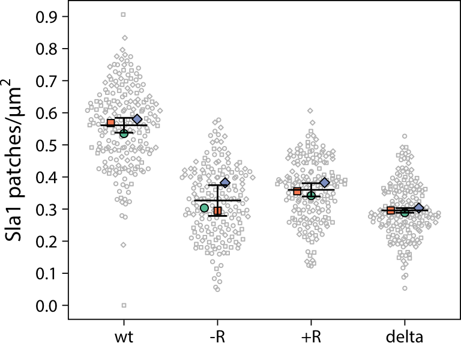

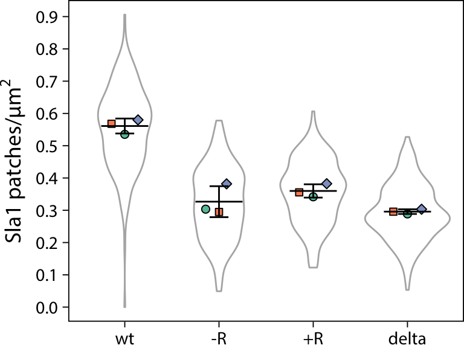

### SuperPlots with significance

Let’s add significance stars based on Tukey’s test.

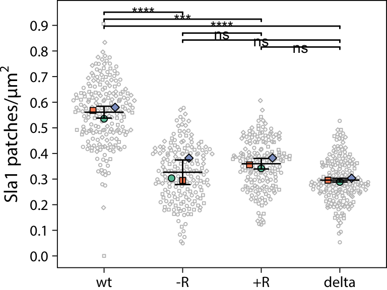

#### Letter annotations

In this view, groups sharing at least one letter are not significant at a chosen $\alpha$ (here, 5%).

Pros:

- less cluttered
- simpler to read and edit

Cons:

- cannot distinguish different confidence levels
- focus on non-findings

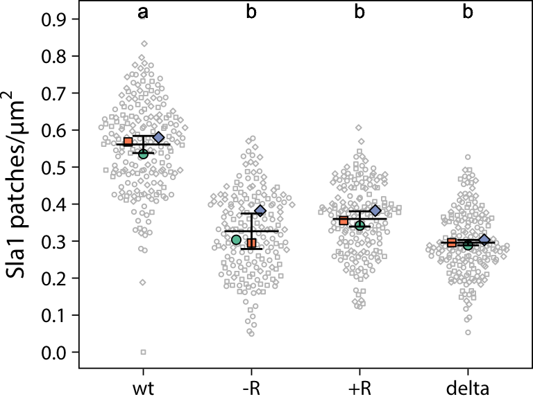

## Source data

### .csv

Download syp1_fusion_sla1.csv

### .RData

Download syp1_fusion_sla1.RData